# Descubrimiento principal: GSE78220 RNA-seq tumor anti-PD-1

TFM Melanoma Inmunoterapia

2026-05-12

# 1 Objetivo

Este informe implementa el nuevo analisis principal propuesto por la tutora: usar `GSE78220` como cohorte de descubrimiento, al ser tumor, RNA-seq, anti-PD-1 y transcriptoma completo.

La finalidad es evitar que el analisis principal quede limitado por los genes incluidos en paneles NanoString y mantener una pregunta biologica mas homogenea: respondedores vs no respondedores a anti-PD-1 en tumor.

## 1.1 Ficha del informe

| Elemento | Detalle |
| --- | --- |
| Entrada | `SummarizedExperiment_objects/se_gse78220.rds` |
| Cohorte | Tumor, RNA-seq, anti-PD-1 |
| Analisis principal | DEA respondedores vs no respondedores con `limma` |
| Modelo exploratorio | Firma transcriptomica con LOOCV y seleccion interna de genes |
| Salida | `resultados/discovery_GSE78220/` |
| Uso posterior | Validar genes/firma en GSE215868 y GSE211645 |

# 2 Librerias

```r
required_packages <- c(
  "SummarizedExperiment",
  "limma",
  "dplyr",
  "tibble",
  "ggplot2",
  "knitr",
  "matrixStats",
  "tidyr",
  "here",
  "AnnotationDbi",
  "org.Hs.eg.db",
  "clusterProfiler"
)

for (pkg in required_packages) {
  if (!requireNamespace(pkg, quietly = TRUE)) {
    stop(paste("Falta instalar el paquete:", pkg))
  }
}

library(SummarizedExperiment)
library(limma)
library(dplyr)
library(tibble)
library(ggplot2)
library(knitr)
library(matrixStats)
library(tidyr)
library(here)
```

# 3 Rutas y carga de datos

```r
project_root <- here::here()
se_path <- file.path(project_root, "SummarizedExperiment_objects", "se_gse78220.rds")
output_dir <- file.path(project_root, "resultados", "discovery_GSE78220")

dir.create(output_dir, recursive = TRUE, showWarnings = FALSE)

file.exists(se_path)
```

```
## [1] TRUE
```

```r
se <- readRDS(se_path)
stopifnot(inherits(se, "SummarizedExperiment"))

se
```

```
## class: SummarizedExperiment
## dim: 25268 25
## metadata(7): dataset description ... preprocessing date_created
## assays(1): expr
## rownames(25268): A1BG A1BG-AS1 ... ZZEF1 ZZZ3
## rowData names(1): gene_symbol
## colnames(25): Pt1 Pt2 ... Pt37 Pt38
## colData names(7): sample_id patient_id ... tissue platform
```

# 4 Validaciones iniciales

```r
dim(se)
```

```
## [1] 25268    25
```

```r
assayNames(se)
```

```
## [1] "expr"
```

```r
colnames(colData(se))
```

```
## [1] "sample_id"       "patient_id"      "response_raw"    "response_binary"
## [5] "dataset"         "tissue"          "platform"
```

```r
head(rowData(se))
```

```
## DataFrame with 6 rows and 1 column
##          gene_symbol
##          <character>
## A1BG            A1BG
## A1BG-AS1    A1BG-AS1
## A1CF            A1CF
## A2M              A2M
## A2M-AS1      A2M-AS1
## A2ML1          A2ML1
```

```r
required_vars <- c("response_binary", "dataset", "tissue", "platform")
missing_vars <- setdiff(required_vars, colnames(colData(se)))

if (length(missing_vars) > 0) {
  stop("Faltan variables necesarias: ", paste(missing_vars, collapse = ", "))
}

cd <- as.data.frame(colData(se)) %>%
  rownames_to_column("sample_id_model")

kable(
  tibble(
    variable = c("dataset", "tissue", "platform"),
    valores = c(
      paste(unique(cd$dataset), collapse = ", "),
      paste(unique(cd$tissue), collapse = ", "),
      paste(unique(cd$platform), collapse = ", ")
    )
  ),
  caption = "Variables tecnicas principales"
)
```

Variables tecnicas principales

| variable | valores |
| --- | --- |
| dataset | GSE78220 |
| tissue | Tumor |
| platform | RNA-seq |

```r
cd %>%
  count(response_raw, response_binary, name = "n") %>%
  kable(caption = "Respuesta cruda y respuesta binaria")
```

Respuesta cruda y respuesta binaria

| response_raw | response_binary | n |
| --- | --- | --- |
| Complete Response | Responder | 3 |
| Partial Response | Responder | 10 |
| Progressive Disease | No_responder | 12 |

# 5 Preparacion de expresion y respuesta

```r
prepare_expression <- function(se_obj, min_fpkm = 1, min_samples = NULL) {
  expr <- assay(se_obj, "expr")
  expr <- as.matrix(expr)
  mode(expr) <- "numeric"
  n_rows_original <- nrow(expr)

  gene_symbols <- as.character(rowData(se_obj)$gene_symbol)
  gene_symbols[is.na(gene_symbols) | trimws(gene_symbols) == ""] <- rownames(expr)[is.na(gene_symbols) | trimws(gene_symbols) == ""]
  gene_symbols <- toupper(trimws(gene_symbols))
  n_duplicate_symbols <- sum(duplicated(gene_symbols[!is.na(gene_symbols) & gene_symbols != ""]))

  expr_df <- as.data.frame(expr, check.names = FALSE)
  expr_df$gene_symbol <- gene_symbols

  expr_collapsed <- expr_df %>%
    filter(!is.na(gene_symbol), gene_symbol != "") %>%
    group_by(gene_symbol) %>%
    summarise(across(where(is.numeric), ~ mean(.x, na.rm = TRUE)), .groups = "drop")

  genes <- expr_collapsed$gene_symbol
  expr_mat <- as.matrix(expr_collapsed[, setdiff(colnames(expr_collapsed), "gene_symbol"), drop = FALSE])
  rownames(expr_mat) <- genes
  expr_linear <- expr_mat

  # La metadata del objeto indica FPKM; se trata como escala lineal de RNA-seq
  # y se transforma a log2(FPKM+1) antes del modelo limma.

  # Los datos de GSE78220 estÃ¡n en escala FPKM lineal: se aplica log2(x+1)
  # para estabilizar la varianza y cumplir los supuestos de limma.
  expr_mat <- log2(expr_mat + 1)

  if (is.null(min_samples)) {
    min_samples <- max(3, ceiling(0.20 * ncol(expr_mat)))
  }

  na_genes <- rowSums(is.na(expr_mat)) > 0
  zero_var_genes <- matrixStats::rowVars(expr_mat, na.rm = TRUE) == 0
  low_expr_genes <- rowSums(expr_linear >= min_fpkm, na.rm = TRUE) < min_samples
  keep_genes <- !na_genes & !zero_var_genes & !low_expr_genes

  qc_summary <- tibble(
    paso = c(
      "Genes/filas originales",
      "Simbolos duplicados colapsados",
      "Genes tras colapsar simbolos",
      "Genes retirados por NA",
      "Genes retirados por varianza cero",
      paste0("Genes retirados por baja expresion (FPKM < ", min_fpkm,
             " en al menos ", min_samples, " muestras)"),
      "Genes retenidos para DEA"
    ),
    valor = c(
      n_rows_original,
      n_duplicate_symbols,
      nrow(expr_mat),
      sum(na_genes),
      sum(zero_var_genes),
      sum(low_expr_genes),
      sum(keep_genes)
    )
  )

  list(
    expr = expr_mat[keep_genes, , drop = FALSE],
    expr_log_unfiltered = expr_mat[!na_genes & !zero_var_genes, , drop = FALSE],
    expr_linear_collapsed = expr_linear,
    qc = qc_summary,
    min_fpkm = min_fpkm,
    min_samples = min_samples
  )
}

prepared <- prepare_expression(se)
expr <- prepared$expr
expr_unfiltered <- prepared$expr_log_unfiltered

response_group <- factor(cd$response_binary)
response_group <- relevel(response_group, ref = "No_responder")

stopifnot(ncol(expr) == nrow(cd))
stopifnot(nlevels(response_group) == 2)

kable(prepared$qc, caption = "Control de calidad y filtrado de expresion")
```

Control de calidad y filtrado de expresion

| paso | valor |
| --- | --- |
| Genes/filas originales | 25268 |
| Simbolos duplicados colapsados | 0 |
| Genes tras colapsar simbolos | 25268 |
| Genes retirados por NA | 0 |
| Genes retirados por varianza cero | 2663 |
| Genes retirados por baja expresion (FPKM < 1 en al menos 5 muestras) | 10719 |
| Genes retenidos para DEA | 14549 |

```r
kable(
  tibble(
    elemento = c("Genes tras control de calidad", "Muestras", "Respondedores", "No respondedores"),
    valor = c(
      nrow(expr),
      ncol(expr),
      sum(response_group == "Responder"),
      sum(response_group == "No_responder")
    )
  ),
  caption = "Dimensiones del analisis de descubrimiento"
)
```

Dimensiones del analisis de descubrimiento

| elemento | valor |
| --- | --- |
| Genes tras control de calidad | 14549 |
| Muestras | 25 |
| Respondedores | 13 |
| No respondedores | 12 |

# 6 Analisis exploratorio y control de calidad

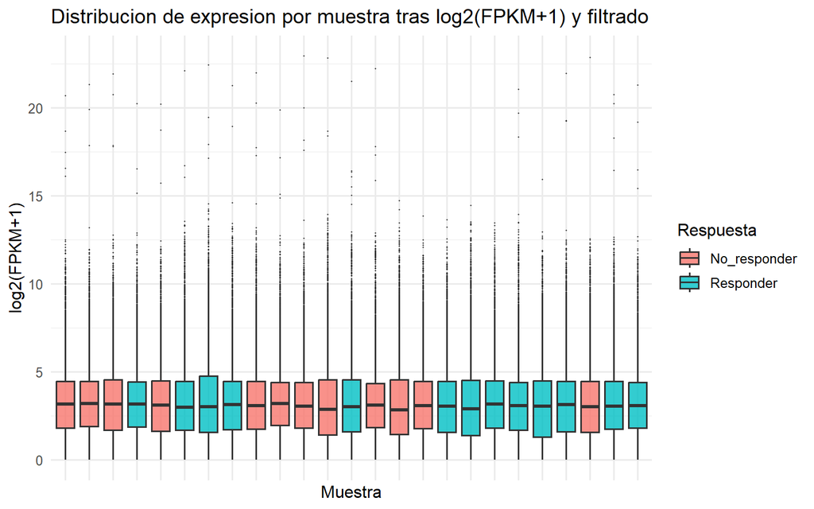

```r
expr_long <- as.data.frame(expr, check.names = FALSE) %>%
  rownames_to_column("gene") %>%
  pivot_longer(-gene, names_to = "sample_id", values_to = "log2_expression") %>%
  left_join(
    cd %>% select(sample_id_model, response_binary),
    by = c("sample_id" = "sample_id_model")
  )

ggplot(expr_long, aes(x = sample_id, y = log2_expression, fill = response_binary)) +
  geom_boxplot(outlier.size = 0.2, alpha = 0.8) +
  labs(
    title = "Distribucion de expresion por muestra tras log2(FPKM+1) y filtrado",
    x = "Muestra",
    y = "log2(FPKM+1)",
    fill = "Respuesta"
  ) +
  theme_minimal(base_size = 12) +
  theme(axis.text.x = element_blank(), axis.ticks.x = element_blank())
```

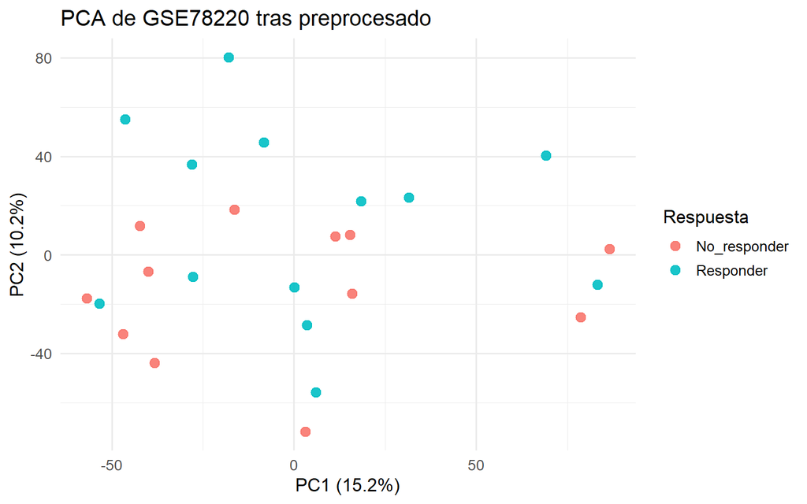

```r
pca_res <- prcomp(t(expr), center = TRUE, scale. = FALSE)
pca_var <- round(summary(pca_res)$importance[2, 1:2] * 100, 1)

pca_df <- as.data.frame(pca_res$x[, 1:2, drop = FALSE]) %>%
  rownames_to_column("sample_id") %>%
  left_join(
    cd %>% select(sample_id_model, response_binary),
    by = c("sample_id" = "sample_id_model")
  )

write.csv(pca_df, file.path(output_dir, "GSE78220_QC_PCA_scores.csv"), row.names = FALSE)

ggplot(pca_df, aes(x = PC1, y = PC2, color = response_binary)) +
  geom_point(size = 3, alpha = 0.9) +
  labs(
    title = "PCA de GSE78220 tras preprocesado",
    x = paste0("PC1 (", pca_var[1], "%)"),
    y = paste0("PC2 (", pca_var[2], "%)"),
    color = "Respuesta"
  ) +
  theme_minimal(base_size = 13)
```

# 7 DEA con limma

```r
run_limma_dea <- function(expr_matrix, response) {
  response <- factor(response)
  response <- relevel(response, ref = "No_responder")

  design <- model.matrix(~ 0 + response)
  colnames(design) <- make.names(colnames(design))

  contrast <- makeContrasts(
    responseResponder - responseNo_responder,
    levels = design
  )

  fit <- lmFit(expr_matrix, design)
  fit2 <- contrasts.fit(fit, contrast)
  fit2 <- eBayes(fit2)

  res <- topTable(fit2, coef = 1, number = Inf, adjust.method = "BH", sort.by = "none") %>%
    rownames_to_column("gene") %>%
    arrange(adj.P.Val, P.Value)

  list(results = res, design = design, fit = fit2)
}

dea <- run_limma_dea(expr, response_group)
res_dea <- dea$results

res_dea %>%
  head(25) %>%
  kable(digits = 4, caption = "Top 25 genes en GSE78220")
```

Top 25 genes en GSE78220

| gene | logFC | AveExpr | t | P.Value | adj.P.Val | B |
| --- | --- | --- | --- | --- | --- | --- |
| ALDH1L2 | -1.2820 | 1.4847 | -4.4659 | 0.0001 | 0.7635 | -3.8589 |
| MFAP2 | -2.9010 | 4.5388 | -4.4493 | 0.0001 | 0.7635 | -3.8625 |
| CDH1 | 3.3021 | 3.5659 | 4.3893 | 0.0002 | 0.7635 | -3.8754 |
| MAP2K5 | 0.7624 | 3.4225 | 4.2339 | 0.0002 | 0.8671 | -3.9093 |
| FBLN2 | -1.8177 | 3.5012 | -4.0659 | 0.0004 | 0.9990 | -3.9467 |
| H1F0 | -1.6178 | 6.4392 | -4.0160 | 0.0004 | 0.9990 | -3.9580 |
| TRAF3IP2 | 1.1962 | 2.9420 | 3.8814 | 0.0006 | 0.9990 | -3.9887 |
| OLIG1 | 1.9874 | 1.9110 | 3.7427 | 0.0009 | 0.9990 | -4.0207 |
| FBLN1 | -2.4290 | 5.2970 | -3.7329 | 0.0009 | 0.9990 | -4.0229 |
| SLC16A3 | -1.8466 | 5.3270 | -3.6442 | 0.0011 | 0.9990 | -4.0436 |
| ANO1 | -1.1969 | 2.0686 | -3.6299 | 0.0012 | 0.9990 | -4.0470 |
| MXRA8 | -1.9239 | 4.4682 | -3.5902 | 0.0013 | 0.9990 | -4.0563 |
| CILP2 | -0.9446 | 0.9746 | -3.5840 | 0.0013 | 0.9990 | -4.0577 |
| RASL12 | -1.1048 | 1.8659 | -3.5600 | 0.0014 | 0.9990 | -4.0634 |
| AXL | -1.4095 | 3.0918 | -3.5343 | 0.0015 | 0.9990 | -4.0694 |
| TIMP3 | -1.4771 | 6.3644 | -3.4977 | 0.0016 | 0.9990 | -4.0781 |
| PDGFRB | -1.2774 | 3.8946 | -3.4673 | 0.0018 | 0.9990 | -4.0853 |
| JMJD7 | 0.9140 | 2.6563 | 3.4659 | 0.0018 | 0.9990 | -4.0856 |
| MIR503HG | -0.8827 | 1.1402 | -3.4612 | 0.0018 | 0.9990 | -4.0867 |
| COL6A3 | -1.6975 | 5.4204 | -3.4353 | 0.0019 | 0.9990 | -4.0928 |
| HTRA3 | -1.7065 | 2.9838 | -3.4239 | 0.0020 | 0.9990 | -4.0955 |
| PPA2 | 0.6559 | 4.6846 | 3.4130 | 0.0020 | 0.9990 | -4.0981 |
| CIPC | 0.6732 | 3.0219 | 3.3846 | 0.0022 | 0.9990 | -4.1048 |
| LYSMD2 | 0.9696 | 3.4727 | 3.3794 | 0.0022 | 0.9990 | -4.1061 |
| PKDCC | -1.1534 | 2.1909 | -3.3430 | 0.0024 | 0.9990 | -4.1147 |

```r
logfc_cutoff <- 0.5
adjp_cutoff <- 0.05
p_cutoff <- 0.05

dea_summary <- res_dea %>%
  mutate(
    significant_fdr = adj.P.Val < adjp_cutoff & abs(logFC) >= logfc_cutoff,
    nominal = P.Value < p_cutoff & abs(logFC) >= logfc_cutoff,
    direction = case_when(
      logFC > 0 ~ "Mayor en respondedores",
      logFC < 0 ~ "Mayor en no respondedores",
      TRUE ~ "Sin cambio"
    )
  ) %>%
  summarise(
    n_genes = n(),
    n_fdr = sum(significant_fdr, na.rm = TRUE),
    n_nominal = sum(nominal, na.rm = TRUE),
    min_adjP = min(adj.P.Val, na.rm = TRUE),
    min_P = min(P.Value, na.rm = TRUE)
  )

kable(dea_summary, digits = 4, caption = "Resumen del DEA en GSE78220")
```

Resumen del DEA en GSE78220

| n_genes | n_fdr | n_nominal | min_adjP | min_P |
| --- | --- | --- | --- | --- |
| 14549 | 0 | 539 | 0.7635 | 1e-04 |

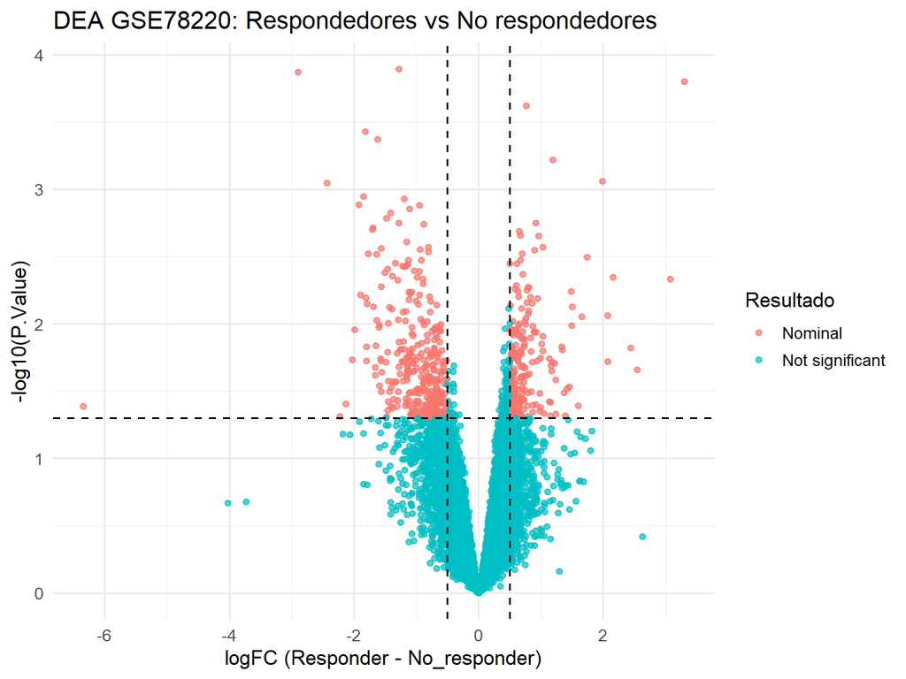

```r
res_dea %>%
  mutate(
    neg_log10_P = -log10(P.Value),
    grupo = case_when(
      adj.P.Val < adjp_cutoff & logFC >= logfc_cutoff ~ "Up in responders (FDR)",
      adj.P.Val < adjp_cutoff & logFC <= -logfc_cutoff ~ "Down in responders (FDR)",
      P.Value < p_cutoff & abs(logFC) >= logfc_cutoff ~ "Nominal",
      TRUE ~ "Not significant"
    )
  ) %>%
  ggplot(aes(x = logFC, y = neg_log10_P, color = grupo)) +
  geom_point(alpha = 0.7, size = 1.5) +
  geom_vline(xintercept = c(-logfc_cutoff, logfc_cutoff), linetype = "dashed") +
  geom_hline(yintercept = -log10(p_cutoff), linetype = "dashed") +
  labs(
    title = "DEA GSE78220: Respondedores vs No respondedores",
    x = "logFC (Responder - No_responder)",
    y = "-log10(P.Value)",
    color = "Resultado"
  ) +
  theme_minimal(base_size = 13)
```

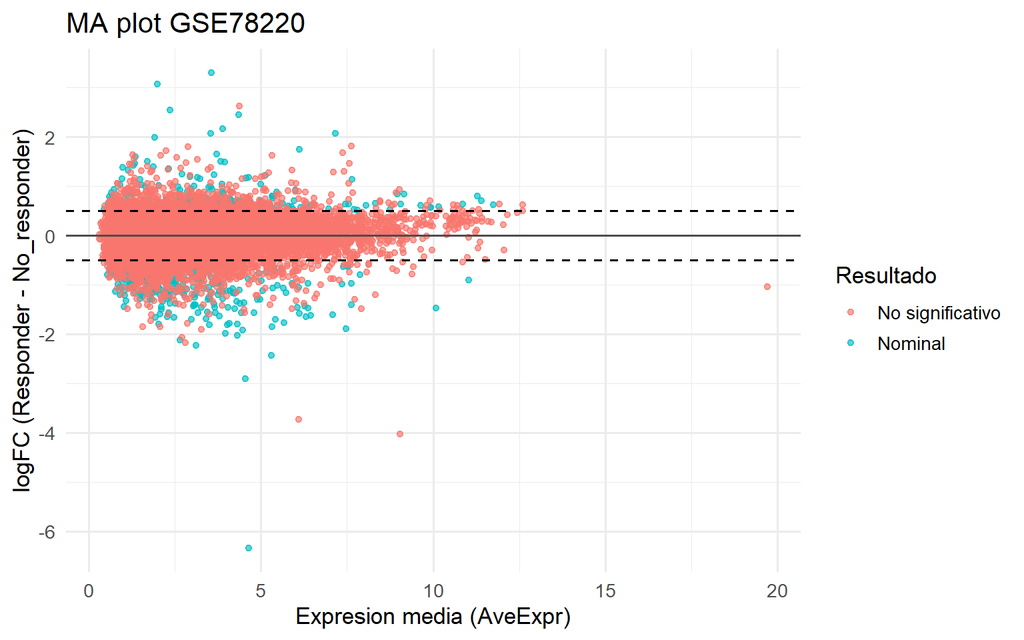

```r
res_dea %>%
  mutate(
    grupo = case_when(
      adj.P.Val < adjp_cutoff & abs(logFC) >= logfc_cutoff ~ "FDR",
      P.Value < p_cutoff & abs(logFC) >= logfc_cutoff ~ "Nominal",
      TRUE ~ "No significativo"
    )
  ) %>%
  ggplot(aes(x = AveExpr, y = logFC, color = grupo)) +
  geom_point(alpha = 0.65, size = 1.4) +
  geom_hline(yintercept = 0, color = "grey30") +
  geom_hline(yintercept = c(-logfc_cutoff, logfc_cutoff), linetype = "dashed") +
  labs(
    title = "MA plot GSE78220",
    x = "Expresion media (AveExpr)",
    y = "logFC (Responder - No_responder)",
    color = "Resultado"
  ) +
  theme_minimal(base_size = 13)
```

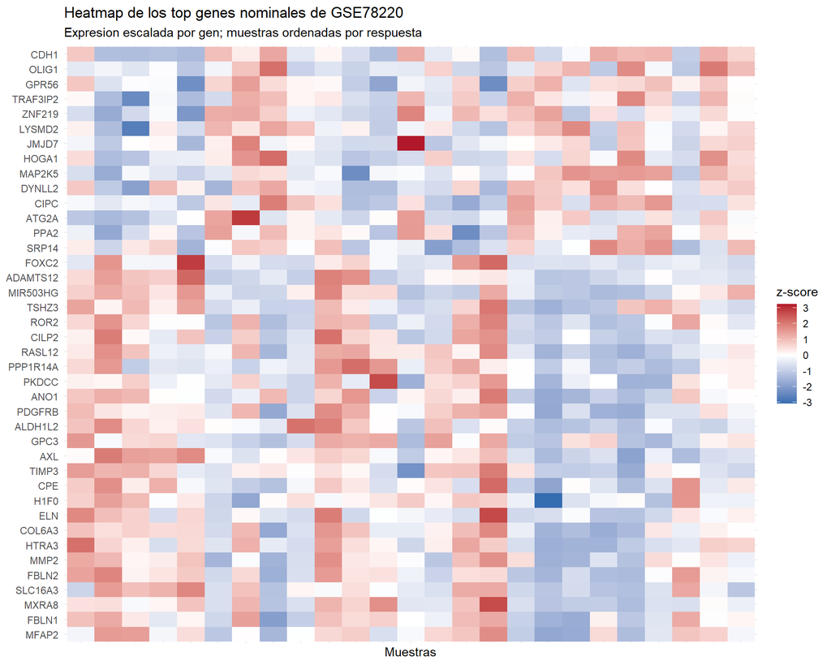

```r
top_heatmap_genes <- res_dea %>%
  filter(P.Value < p_cutoff, abs(logFC) >= logfc_cutoff) %>%
  arrange(P.Value) %>%
  slice_head(n = 40) %>%
  pull(gene)

heat_df <- NULL

if (length(top_heatmap_genes) >= 2) {
  expr_heat <- expr[top_heatmap_genes, , drop = FALSE]
  expr_heat_z <- t(scale(t(expr_heat)))
  expr_heat_z[!is.finite(expr_heat_z)] <- 0

  sample_order <- cd %>%
    mutate(response_binary = factor(response_binary, levels = c("No_responder", "Responder"))) %>%
    arrange(response_binary, sample_id_model) %>%
    pull(sample_id_model)
  sample_order <- intersect(sample_order, colnames(expr_heat_z))

  gene_order <- res_dea %>%
    filter(gene %in% top_heatmap_genes) %>%
    arrange(desc(logFC)) %>%
    pull(gene)
  heat_df <- data.frame(.ready = TRUE)
} else {
  heat_df <- NULL
}

if (!is.null(heat_df)) {
  heat_df <- as.data.frame(expr_heat_z[gene_order, sample_order, drop = FALSE], check.names = FALSE) %>%
    rownames_to_column("gene") %>%
    pivot_longer(-gene, names_to = "sample_id", values_to = "z_score") %>%
    mutate(
      gene = factor(gene, levels = rev(gene_order)),
      sample_id = factor(sample_id, levels = sample_order)
    ) %>%
    left_join(
      cd %>% select(sample_id_model, response_binary),
      by = c("sample_id" = "sample_id_model")
    )

  ggplot(heat_df, aes(x = sample_id, y = gene, fill = z_score)) +
    geom_tile() +
    scale_fill_gradient2(low = "#2166ac", mid = "white", high = "#b2182b", midpoint = 0) +
    labs(
      title = "Heatmap de los top genes nominales de GSE78220",
      subtitle = "Expresion escalada por gen; muestras ordenadas por respuesta",
      x = "Muestras",
      y = NULL,
      fill = "z-score"
    ) +
    theme_minimal(base_size = 11) +
    theme(axis.text.x = element_blank(), axis.ticks.x = element_blank())
} else {
  cat("No hay suficientes genes nominales para construir el heatmap.\n")
}
```

# 8 Enriquecimiento funcional exploratorio

Como el tamanio muestral de `GSE78220` es reducido, no se esperan genes significativos tras FDR. Por ello, el enriquecimiento se interpreta como analisis exploratorio sobre genes nominales, usando todos los genes testados como universo.

```r
map_symbols_to_entrez <- function(symbols) {
  symbols <- unique(toupper(trimws(symbols)))
  symbols <- symbols[!is.na(symbols) & symbols != ""]

  suppressMessages(
    AnnotationDbi::select(
      org.Hs.eg.db::org.Hs.eg.db,
      keys = symbols,
      columns = c("SYMBOL", "ENTREZID"),
      keytype = "SYMBOL"
    )
  ) %>%
    filter(!is.na(ENTREZID), ENTREZID != "") %>%
    distinct(SYMBOL, ENTREZID)
}

run_go_ora <- function(gene_symbols, universe_symbols, direction_label) {
  gene_map <- map_symbols_to_entrez(gene_symbols)
  universe_map <- map_symbols_to_entrez(universe_symbols)

  gene_entrez <- unique(gene_map$ENTREZID)
  universe_entrez <- unique(universe_map$ENTREZID)

  if (length(gene_entrez) < 5 || length(universe_entrez) < 20) {
    return(tibble())
  }

  ora <- clusterProfiler::enrichGO(
    gene = gene_entrez,
    universe = universe_entrez,
    OrgDb = org.Hs.eg.db::org.Hs.eg.db,
    keyType = "ENTREZID",
    ont = "BP",
    pAdjustMethod = "BH",
    pvalueCutoff = 0.10,
    qvalueCutoff = 0.25,
    readable = TRUE
  )

  out <- as.data.frame(ora)
  if (nrow(out) == 0) {
    return(tibble())
  }

  out %>%
    as_tibble() %>%
    mutate(direction = direction_label)
}

genes_up_nominal <- res_dea %>%
  filter(P.Value < p_cutoff, logFC >= logfc_cutoff) %>%
  pull(gene)

genes_down_nominal <- res_dea %>%
  filter(P.Value < p_cutoff, logFC <= -logfc_cutoff) %>%
  pull(gene)

universe_genes <- res_dea$gene

ora_up <- run_go_ora(genes_up_nominal, universe_genes, "Up en respondedores")
ora_down <- run_go_ora(genes_down_nominal, universe_genes, "Down en respondedores")
ora_all <- bind_rows(ora_up, ora_down)

write.csv(ora_up, file.path(output_dir, "GSE78220_ORA_GO_BP_up_nominal.csv"), row.names = FALSE)
write.csv(ora_down, file.path(output_dir, "GSE78220_ORA_GO_BP_down_nominal.csv"), row.names = FALSE)
write.csv(ora_all, file.path(output_dir, "GSE78220_ORA_GO_BP_nominal_combined.csv"), row.names = FALSE)

ora_summary <- tibble(
  contraste = c("Up en respondedores", "Down en respondedores"),
  n_genes_nominales = c(length(unique(genes_up_nominal)), length(unique(genes_down_nominal))),
  n_terminos_GO = c(nrow(ora_up), nrow(ora_down))
)

kable(ora_summary, caption = "Resumen del enriquecimiento GO BP exploratorio")
```

Resumen del enriquecimiento GO BP exploratorio

| contraste | n_genes_nominales | n_terminos_GO |
| --- | --- | --- |
| Up en respondedores | 209 | 13 |
| Down en respondedores | 330 | 422 |

```r
if (nrow(ora_all) > 0) {
  ora_all %>%
    group_by(direction) %>%
    arrange(p.adjust, .by_group = TRUE) %>%
    slice_head(n = 10) %>%
    ungroup() %>%
    select(direction, ID, Description, GeneRatio, Count, pvalue, p.adjust) %>%
    kable(digits = 4, caption = "Top terminos GO BP enriquecidos")
} else {
  cat("No se detectaron terminos GO BP enriquecidos con los umbrales exploratorios definidos.\n")
}
```

Top terminos GO BP enriquecidos

| direction | ID | Description | GeneRatio | Count | pvalue | p.adjust |
| --- | --- | --- | --- | --- | --- | --- |
| Down en respondedores | GO:0030198 | extracellular matrix organization | 44/290 | 44 | 0e+00 | 0.0000 |
| Down en respondedores | GO:0043062 | extracellular structure organization | 44/290 | 44 | 0e+00 | 0.0000 |
| Down en respondedores | GO:0045229 | external encapsulating structure organization | 44/290 | 44 | 0e+00 | 0.0000 |
| Down en respondedores | GO:0001525 | angiogenesis | 43/290 | 43 | 0e+00 | 0.0000 |
| Down en respondedores | GO:0030199 | collagen fibril organization | 15/290 | 15 | 0e+00 | 0.0000 |
| Down en respondedores | GO:0090287 | regulation of cellular response to growth factor stimulus | 27/290 | 27 | 0e+00 | 0.0000 |
| Down en respondedores | GO:0031589 | cell-substrate adhesion | 29/290 | 29 | 0e+00 | 0.0000 |
| Down en respondedores | GO:0001503 | ossification | 31/290 | 31 | 0e+00 | 0.0000 |
| Down en respondedores | GO:0048010 | vascular endothelial growth factor receptor signaling pathway | 16/290 | 16 | 0e+00 | 0.0000 |
| Down en respondedores | GO:0001501 | skeletal system development | 34/290 | 34 | 0e+00 | 0.0000 |
| Up en respondedores | GO:0009063 | amino acid catabolic process | 8/169 | 8 | 0e+00 | 0.0326 |
| Up en respondedores | GO:1901606 | alpha-amino acid catabolic process | 7/169 | 7 | 0e+00 | 0.0326 |
| Up en respondedores | GO:0022904 | respiratory electron transport chain | 8/169 | 8 | 1e-04 | 0.0326 |
| Up en respondedores | GO:0002181 | cytoplasmic translation | 10/169 | 10 | 1e-04 | 0.0326 |
| Up en respondedores | GO:0090407 | organophosphate biosynthetic process | 19/169 | 19 | 1e-04 | 0.0326 |
| Up en respondedores | GO:0019646 | aerobic electron transport chain | 7/169 | 7 | 1e-04 | 0.0326 |
| Up en respondedores | GO:0022900 | electron transport chain | 8/169 | 8 | 1e-04 | 0.0347 |
| Up en respondedores | GO:0006520 | amino acid metabolic process | 11/169 | 11 | 1e-04 | 0.0347 |
| Up en respondedores | GO:0042773 | ATP synthesis coupled electron transport | 7/169 | 7 | 2e-04 | 0.0347 |
| Up en respondedores | GO:0042775 | mitochondrial ATP synthesis coupled electron transport | 7/169 | 7 | 2e-04 | 0.0347 |

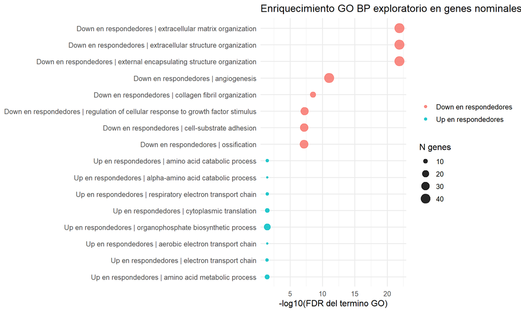

```r
if (nrow(ora_all) > 0) {
  ora_plot <- ora_all %>%
    group_by(direction) %>%
    arrange(p.adjust, .by_group = TRUE) %>%
    slice_head(n = 8) %>%
    ungroup() %>%
    mutate(
      term_label = paste(direction, Description, sep = " | "),
      term_label = factor(term_label, levels = rev(unique(term_label)))
    )

  ggplot(ora_plot, aes(x = -log10(p.adjust), y = term_label, size = Count, color = direction)) +
    geom_point(alpha = 0.85) +
    labs(
      title = "Enriquecimiento GO BP exploratorio en genes nominales",
      x = "-log10(FDR del termino GO)",
      y = NULL,
      size = "N genes",
      color = NULL
    ) +
    theme_minimal(base_size = 12)
} else {
  cat("No se genera grafico de enriquecimiento porque no hay terminos enriquecidos.\n")
}
```

# 9 Modelo predictivo exploratorio

Este bloque no pretende cerrar un modelo clinico definitivo. Con 25 muestras, se usa como evaluacion preliminar de si la seÃ±al transcriptomica permite separar respondedores y no respondedores.

Para reducir fuga de informacion, en cada iteracion leave-one-out se seleccionan genes usando solo el conjunto de entrenamiento.

```r
calc_auc <- function(scores, labels) {
  labels <- factor(labels, levels = c("No_responder", "Responder"))
  y <- as.integer(labels == "Responder")
  n_pos <- sum(y == 1)
  n_neg <- sum(y == 0)
  if (n_pos == 0 || n_neg == 0) return(NA_real_)

  ranks <- rank(scores, ties.method = "average")
  auc <- (sum(ranks[y == 1]) - n_pos * (n_pos + 1) / 2) / (n_pos * n_neg)
  auc
}

score_signature <- function(train_expr, test_expr, train_response, top_n) {
  dea_train <- run_limma_dea(train_expr, train_response)$results
  selected <- dea_train %>%
    arrange(P.Value) %>%
    head(top_n) %>%
    mutate(direction = ifelse(logFC >= 0, 1, -1))

  genes <- selected$gene
  directions <- selected$direction
  names(directions) <- genes

  train_gene_mean <- rowMeans(train_expr[genes, , drop = FALSE], na.rm = TRUE)
  train_gene_sd <- matrixStats::rowSds(train_expr[genes, , drop = FALSE], na.rm = TRUE)
  train_gene_sd[train_gene_sd == 0 | is.na(train_gene_sd)] <- 1

  test_z <- (test_expr[genes] - train_gene_mean) / train_gene_sd
  mean(test_z * directions, na.rm = TRUE)
}

run_loocv_signature <- function(expr_matrix, response, top_n_values = c(5, 10, 20, 50)) {
  sample_ids <- colnames(expr_matrix)

  bind_rows(lapply(top_n_values, function(top_n) {
    predictions <- lapply(seq_along(sample_ids), function(i) {
      test_sample <- sample_ids[i]
      train_samples <- sample_ids[-i]

      train_expr <- expr_matrix[, train_samples, drop = FALSE]
      test_expr <- expr_matrix[, test_sample]
      train_response <- response[-i]

      score <- score_signature(train_expr, test_expr, train_response, top_n)

      tibble(
        top_n = top_n,
        sample_id = test_sample,
        response = as.character(response[i]),
        score = score
      )
    }) %>% bind_rows()

    auc <- calc_auc(predictions$score, predictions$response)
    threshold <- median(predictions$score, na.rm = TRUE)

    predictions %>%
      mutate(
        auc = auc,
        predicted = ifelse(score >= threshold, "Responder", "No_responder"),
        correct = predicted == response
      )
  }))
}

loocv_predictions <- run_loocv_signature(expr, response_group)

loocv_summary <- loocv_predictions %>%
  group_by(top_n) %>%
  summarise(
    auc = first(auc),
    accuracy = mean(correct, na.rm = TRUE),
    .groups = "drop"
  ) %>%
  arrange(desc(auc))

kable(loocv_summary, digits = 3, caption = "Modelo exploratorio LOOCV por numero de genes")
```

Modelo exploratorio LOOCV por numero de genes

| top_n | auc | accuracy |
| --- | --- | --- |
| 5 | 0.853 | 0.76 |
| 10 | 0.686 | 0.60 |
| 50 | 0.571 | 0.60 |
| 20 | 0.558 | 0.44 |

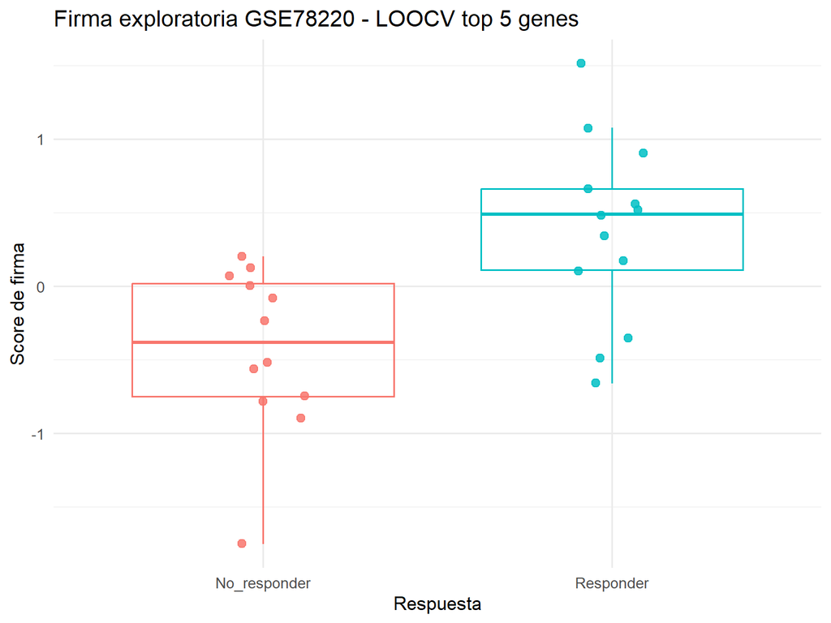

```r
best_top_n <- loocv_summary$top_n[1]

loocv_predictions %>%
  filter(top_n == best_top_n) %>%
  ggplot(aes(x = response, y = score, color = response)) +
  geom_boxplot(outlier.shape = NA, alpha = 0.25) +
  geom_jitter(width = 0.12, size = 2.5, alpha = 0.85) +
  labs(
    title = paste0("Firma exploratoria GSE78220 - LOOCV top ", best_top_n, " genes"),
    x = "Respuesta",
    y = "Score de firma"
  ) +
  theme_minimal(base_size = 13) +
  theme(legend.position = "none")
```

# 10 Guardado de resultados

```r
write.csv(res_dea, file.path(output_dir, "GSE78220_DEA_limma_response.csv"), row.names = FALSE)
write.csv(loocv_predictions, file.path(output_dir, "GSE78220_LOOCV_signature_predictions.csv"), row.names = FALSE)
write.csv(loocv_summary, file.path(output_dir, "GSE78220_LOOCV_signature_summary.csv"), row.names = FALSE)
write.csv(prepared$qc, file.path(output_dir, "GSE78220_expression_QC_summary.csv"), row.names = FALSE)
saveRDS(dea, file.path(output_dir, "GSE78220_DEA_limma_response.rds"))

list.files(output_dir, full.names = TRUE)
```

```
## [1] "C:/Users/sonia/Desktop/2_TFM_MELANOMA/resultados/discovery_GSE78220/GSE78220_DEA_limma_response.csv"
## [2] "C:/Users/sonia/Desktop/2_TFM_MELANOMA/resultados/discovery_GSE78220/GSE78220_DEA_limma_response.rds"
## [3] "C:/Users/sonia/Desktop/2_TFM_MELANOMA/resultados/discovery_GSE78220/GSE78220_expression_QC_summary.csv"
## [4] "C:/Users/sonia/Desktop/2_TFM_MELANOMA/resultados/discovery_GSE78220/GSE78220_LOOCV_signature_predictions.csv"
## [5] "C:/Users/sonia/Desktop/2_TFM_MELANOMA/resultados/discovery_GSE78220/GSE78220_LOOCV_signature_summary.csv"
## [6] "C:/Users/sonia/Desktop/2_TFM_MELANOMA/resultados/discovery_GSE78220/GSE78220_ORA_GO_BP_down_nominal.csv"
## [7] "C:/Users/sonia/Desktop/2_TFM_MELANOMA/resultados/discovery_GSE78220/GSE78220_ORA_GO_BP_nominal_combined.csv"
## [8] "C:/Users/sonia/Desktop/2_TFM_MELANOMA/resultados/discovery_GSE78220/GSE78220_ORA_GO_BP_up_nominal.csv"
## [9] "C:/Users/sonia/Desktop/2_TFM_MELANOMA/resultados/discovery_GSE78220/GSE78220_QC_PCA_scores.csv"
```

# 11 Checklist final

```r
checks <- tibble(
  comprobacion = c(
    "Objeto GSE78220 cargado",
    "Cohorte tumoral",
    "Plataforma RNA-seq",
    "Dos grupos de respuesta",
    "Filtrado de baja expresion documentado",
    "QC PCA guardado",
    "Enriquecimiento GO exploratorio ejecutado",
    "DEA ejecutado sobre transcriptoma completo",
    "Modelo LOOCV generado",
    "Resultados guardados"
  ),
  estado = c(
    inherits(se, "SummarizedExperiment"),
    all(cd$tissue == "Tumor"),
    all(cd$platform == "RNA-seq"),
    nlevels(response_group) == 2,
    file.exists(file.path(output_dir, "GSE78220_expression_QC_summary.csv")),
    file.exists(file.path(output_dir, "GSE78220_QC_PCA_scores.csv")),
    file.exists(file.path(output_dir, "GSE78220_ORA_GO_BP_nominal_combined.csv")),
    nrow(res_dea) > 1000,
    nrow(loocv_predictions) > 0,
    file.exists(file.path(output_dir, "GSE78220_DEA_limma_response.csv"))
  )
)

kable(checks, caption = "Checklist final GSE78220")
```

Checklist final GSE78220

| comprobacion | estado |
| --- | --- |
| Objeto GSE78220 cargado | TRUE |
| Cohorte tumoral | TRUE |
| Plataforma RNA-seq | TRUE |
| Dos grupos de respuesta | TRUE |
| Filtrado de baja expresion documentado | TRUE |
| QC PCA guardado | TRUE |
| Enriquecimiento GO exploratorio ejecutado | TRUE |
| DEA ejecutado sobre transcriptoma completo | TRUE |
| Modelo LOOCV generado | TRUE |
| Resultados guardados | TRUE |

```r
if (!all(checks$estado)) {
  stop("Alguno de los checks finales no se cumple.")
}
```

# 12 Conclusion metodologica

Este informe deja preparado el bloque de descubrimiento principal usando `GSE78220` sin restriccion por panel NanoString. Los genes candidatos y la firma exploratoria obtenidos aqui deben interpretarse como hipotesis de descubrimiento y validarse posteriormente en `GSE215868` y `GSE211645`.

# 13 Informacion de sesion